# Validating ordtpx: Ordered topic model

Kushal K Dey

April 11, 2016

## Overview

In this script, we perform test runs to validate the *ordtpx* package. We take out chunks from the MRA analysis of the *ordtpx* code and then try to dry run or test run these code chunks.

```r
library(ordtpx)
theta_tree <- mra_tree_prior_theta(4, c(1,20,200))
print(theta_tree)
```

```
## [[1]]
## [1] 1
##
## [[2]]
## [1] 0.90074497 0.09925503
##
## [[3]]
## [1] 0.51757419 0.38317078 0.05400249 0.04525254
##
## [[4]]
## [1] 0.26102855 0.25654564 0.19687005 0.18630073 0.02861975 0.02538274
## [7] 0.02446932 0.02078322
```

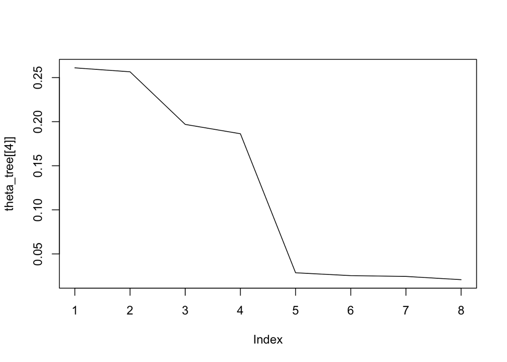

```r
plot(theta_tree[[4]], type="l")
```

Note that the $\Theta$ matrix is pretty smooth because the lower level $\beta$ values are generated from a very concentrated Beta distribution $Beta(200,200)$. If we want less smooth theta, one may take a less concentrated prior at the bottom levels.

```r
theta_tree <- mra_tree_prior_theta(4, c(1,10,20))
print(theta_tree)
```

```
## [[1]]
## [1] 1
##
## [[2]]
## [1] 0.8199191 0.1800809
##
## [[3]]
## [1] 0.44741999 0.37249912 0.05972014 0.12036075
##
## [[4]]
## [1] 0.22273504 0.22468496 0.14538932 0.22710980 0.02941657 0.03030358
## [7] 0.05237611 0.06798464
```

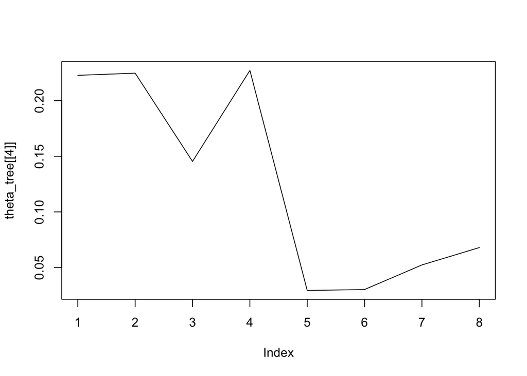

```r
plot(theta_tree[[4]], type="l")
```

We now build the mu tree over the theta tree we generate above.

```r
mu_tree <- mra_tree_prior_mu(4, c(1,20,200),2,2);
print(mu_tree)
```

```
## [[1]]
## [1] 0.5794518
##
## [[2]]
## [1] 0.52941297 0.05003883
##
## [[3]]
## [1] 0.28669740 0.24271557 0.02193316 0.02810566
##
## [[4]]
## [1] 0.14355811 0.14313929 0.11640418 0.12631139 0.01079428 0.01113889
## [7] 0.01391147 0.01419419
```

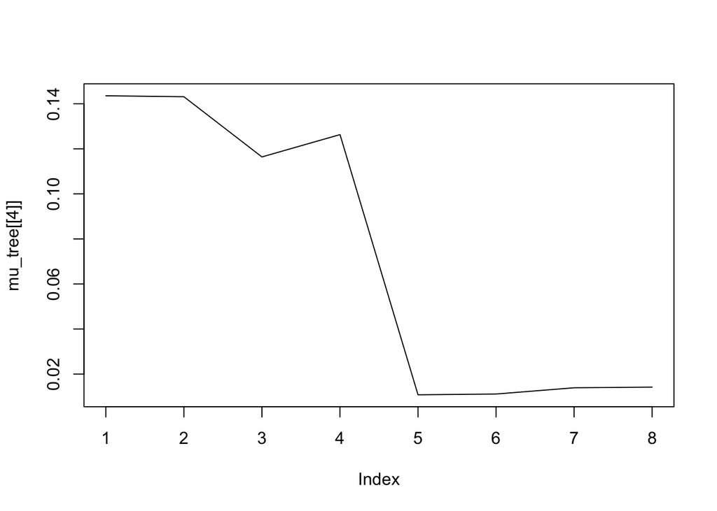

```r
plot(mu_tree[[4]], type="l")
```

We extract the theta tree from the mu tree we generated. The shape of the extracted theta would be similar to that of the mu (lower level)

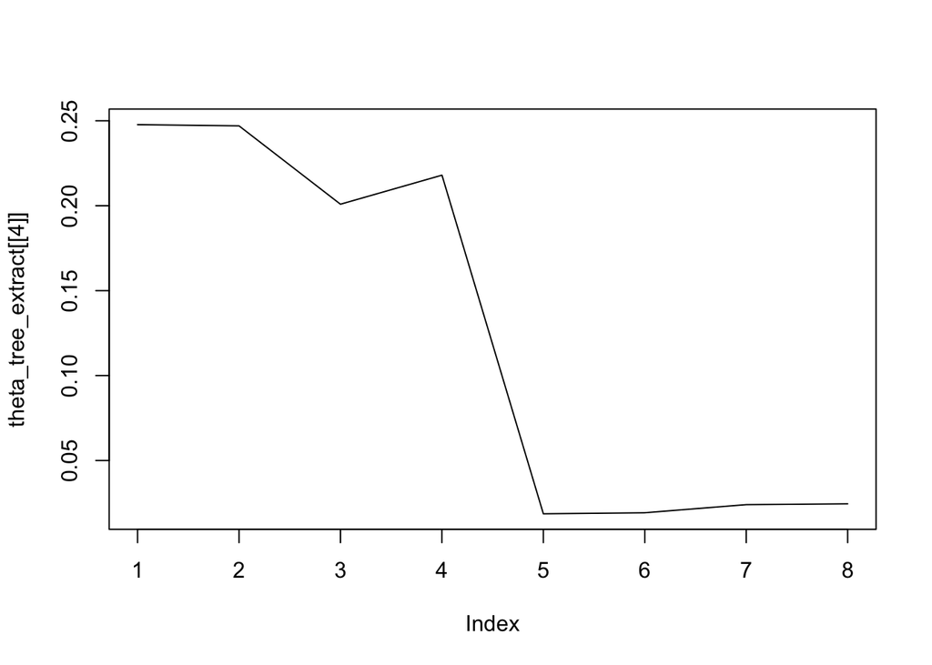

```r
theta_tree_extract <- extract_theta_tree_from_mu(mu_tree)
plot(theta_tree_extract[[4]], type="l")
```

If we know the leaf node theta/ mu values, we can construct the tree by adding the adjacent values together.

```r
theta_tree <- mra_tree_prior_theta(4, c(1,20,200))
print(theta_tree)
```

```
## [[1]]
## [1] 1
##
## [[2]]
## [1] 0.7546168 0.2453832
##
## [[3]]
## [1] 0.45409960 0.30051724 0.16623823 0.07914493
##
## [[4]]
## [1] 0.22762181 0.22647779 0.14414346 0.15637379 0.08304877 0.08318946
## [7] 0.04050603 0.03863891
```

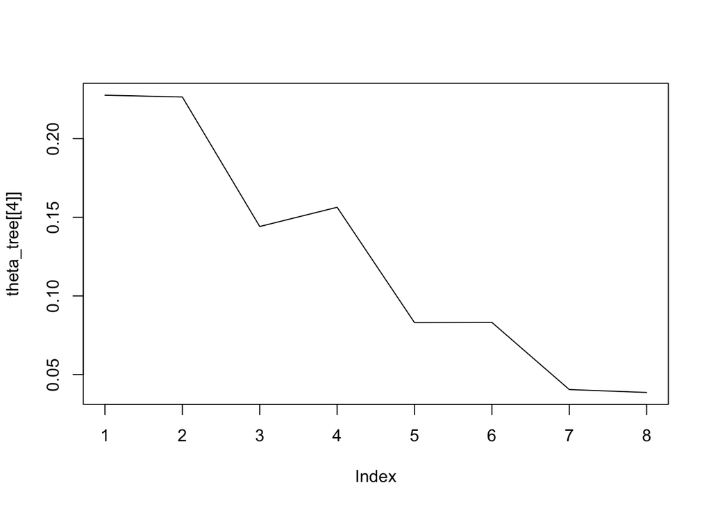

```r
plot(theta_tree[[4]], type="l")
```

```r
theta_tree_construct <- mra_bottom_up(theta_tree[[4]])
print(theta_tree)
```

```
## [[1]]
## [1] 1
##
## [[2]]
## [1] 0.7546168 0.2453832
##
## [[3]]
## [1] 0.45409960 0.30051724 0.16623823 0.07914493
##
## [[4]]
## [1] 0.22762181 0.22647779 0.14414346 0.15637379 0.08304877 0.08318946
## [7] 0.04050603 0.03863891
```

```r
print(theta_tree_construct) ## should be same as theta_tree
```

```
## [[1]]
## [1] 1
##
## [[2]]
## [1] 0.7546168 0.2453832
##
## [[3]]
## [1] 0.45409960 0.30051724 0.16623823 0.07914493
##
## [[4]]
## [1] 0.22762181 0.22647779 0.14414346 0.15637379 0.08304877 0.08318946
## [7] 0.04050603 0.03863891
```

Now we generate counts data using the Multinomial model.

```r
nclus <- 2;
del_beta <- c(2,10,50, 100, 500, 1000, 2000);
levels <- 8

a_mu <- 30;
b_mu <- 80;

mu_tree_set <- lapply(1:nclus, function(s) return(mra_tree_prior_mu(levels,del_beta, a_mu, b_mu)));
param_set <- param_extract_mu_tree(mu_tree_set)

prior_calc <- prior_calc_fn(param_set, del_beta, a_mu, b_mu)

theta_sim <- do.call(rbind, lapply(1:nclus, function(l) mu_tree_set[[l]][[levels]]/mu_tree_set[[l]][[1]]));

n.out <- 200
omega_sim <- rbind( cbind( rep(1, n.out), rep(0, n.out)),
                  cbind( rep(0, n.out), rep(1, n.out)),
                  cbind( seq(0.6, 0.4, length.out = n.out),
                         1- seq(0.6, 0.4,length.out=n.out)) )
dim(omega_sim)
```

```
## [1] 600   2
```

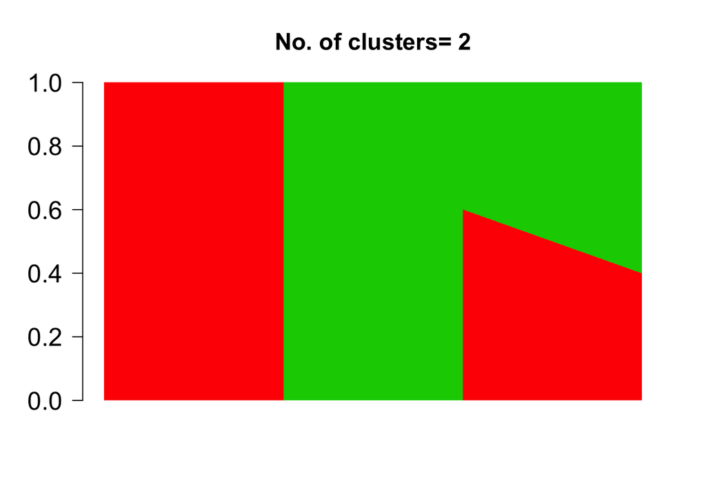

```r
K <- dim(omega_sim)[2]

barplot(t(omega_sim),
        col = 2:(K+1),
        axisnames = F, space = 0, border = NA,
        main=paste("No. of clusters=", K),
        las=1, ylim=c(0,1), cex.axis=1.5, cex.main=1.4)
```

```r
counts <- t(do.call(cbind,lapply(1:dim(omega_sim)[1], function(x) rmultinom(1,1000,prob=omega_sim[x,]%*%theta_sim))));
```

We first apply **maptpx** package.

```r
topic_clus <- maptpx::topics(counts, K=2, tol=0.1)
```

```
##
## Estimating on a 600 document collection.
## Fitting the 2 topic model.
## log posterior increase: 2229.7, 4, 2, 0.3, 0.2, 0.1, done.
```

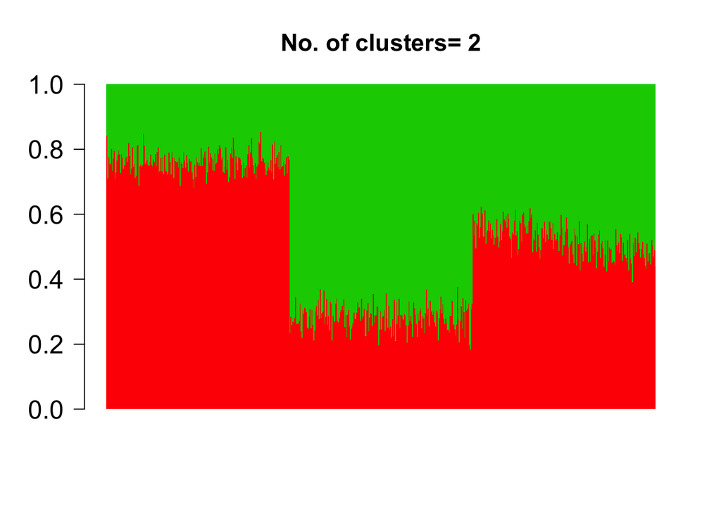

```r
K <- 2
barplot(t(topic_clus$omega),
        col = 2:(K+1),
        axisnames = F, space = 0, border = NA,
        main=paste("No. of clusters=", K),
        las=1, ylim=c(0,1), cex.axis=1.5, cex.main=1.4)
```

We also plot the theta matrices

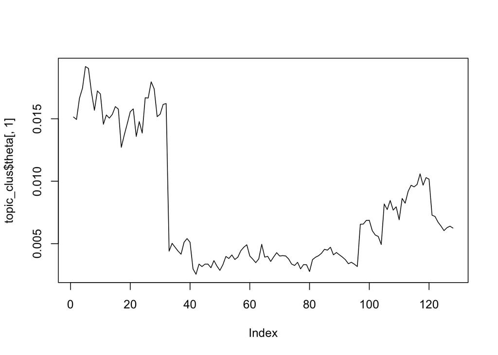

```r
plot(topic_clus$theta[,1], type="l")
```

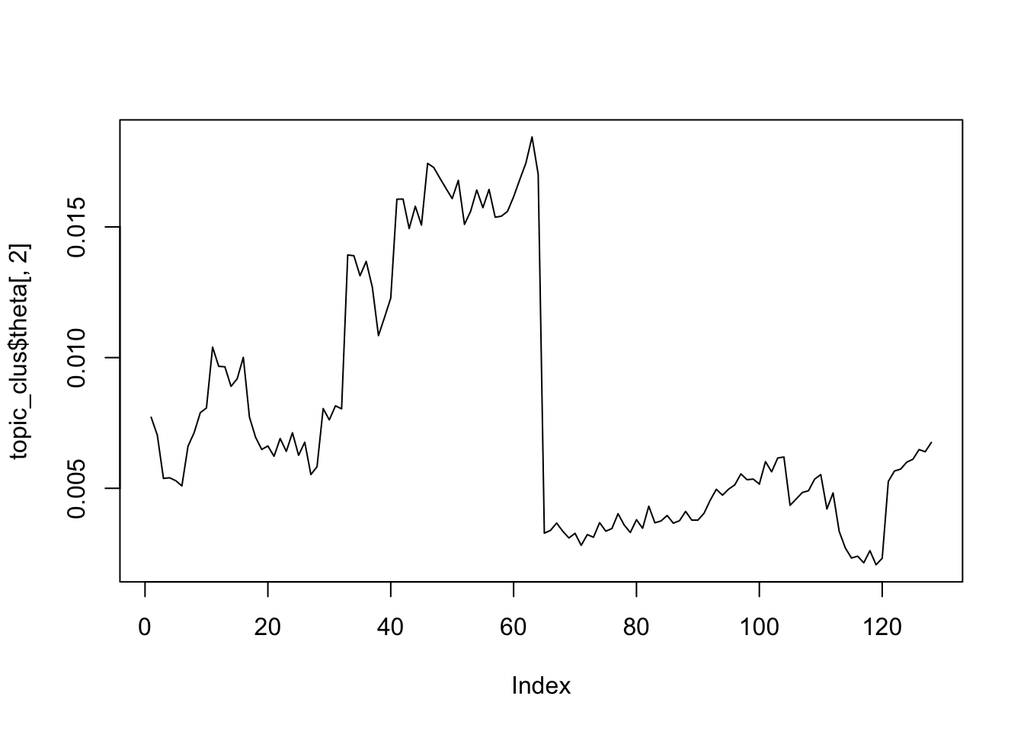

```r
plot(topic_clus$theta[,2], type="l")
```

We now perform *ordtpx*.

```r
library(slam)
# initopics=NULL
# tol=0.1
# ord=TRUE
# ztree_options=1
# verb=1
# reflect=TRUE
# tmax=10000
# wtol=10^(-4)
# qn=100
# grp=NULL
# admix=TRUE
# nonzero=FALSE
# dcut=-10
```

### Scenario 1

```r
K <- 2

del_beta_1 <- c(50, 500, 5000, 50000, 500000, 5000000, 50000000)
system.time(ord_topics <- ord_topics(counts, K=2, del_beta = del_beta_1, a_mu=1, b_mu=3, ztree_options=2, tol=0.001));
```

```
##
## Estimating on a 600 document collection.
##
## Fitting a ordered topic model with 2 topics
## log posterior increase: 127369.228, 0.267, 0.037, done.
```

```
##    user  system elapsed
##   1.418   1.895   2.545
```

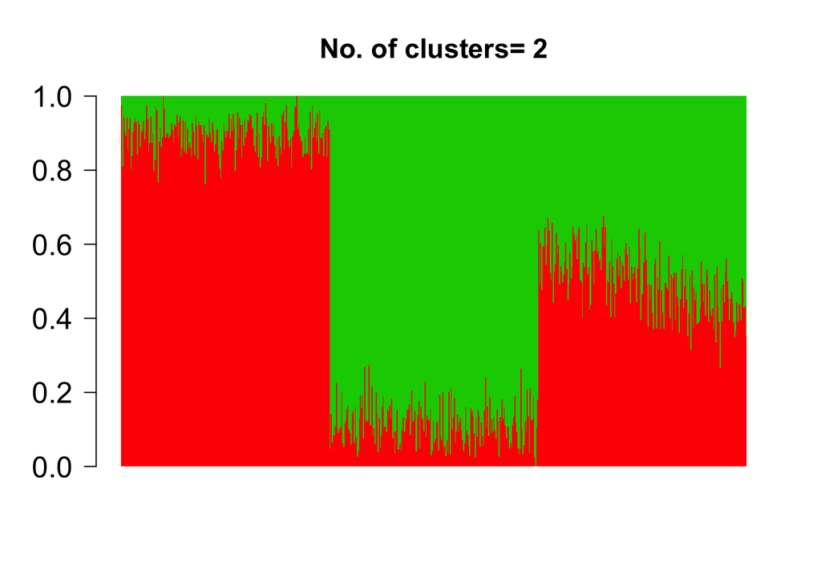

```r
barplot(t(ord_topics$omega),
        col = 2:(K+1),
        axisnames = F, space = 0, border = NA,
        main=paste("No. of clusters=", K),
        las=1, ylim=c(0,1), cex.axis=1.5, cex.main=1.4)
```

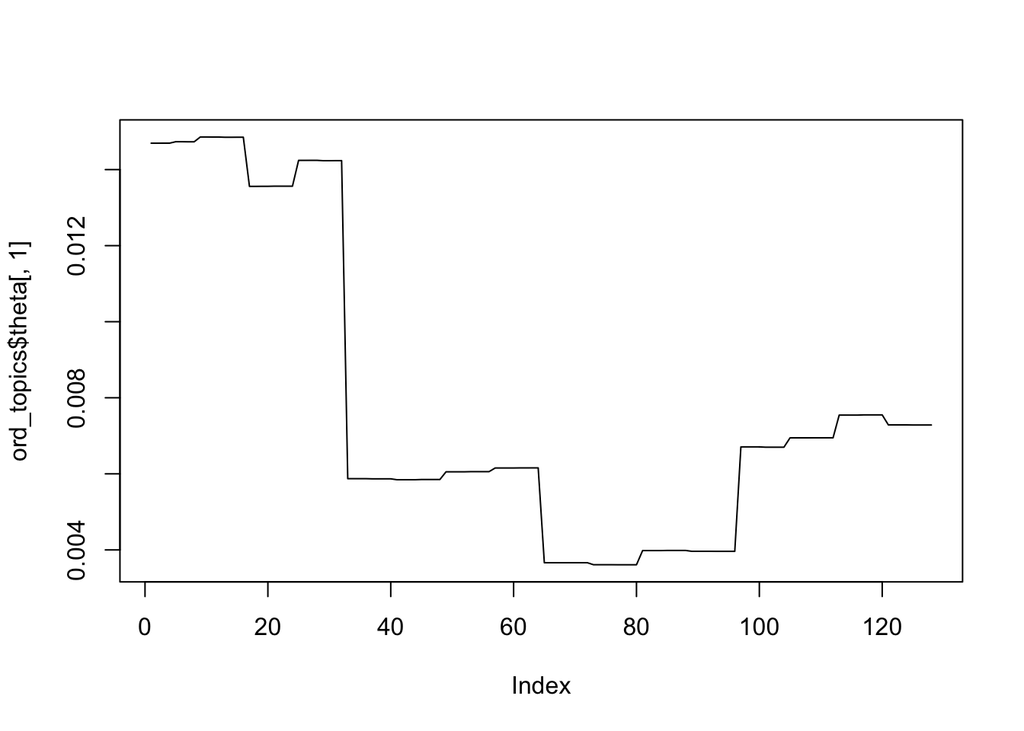

```r
plot(ord_topics$theta[,1], type="l")
```

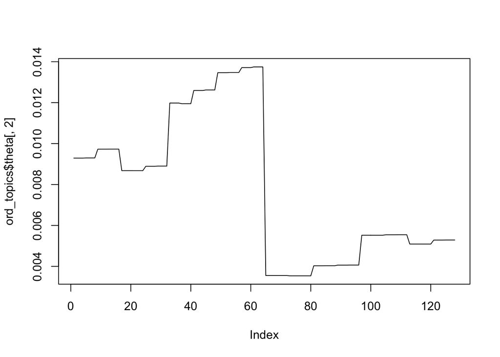

```r
plot(ord_topics$theta[,2], type="l")
```

### Scenario 2

```r
K <- 2

del_beta_1 <- c(50, 500, 5000, 50000, 500000, 5000000, 50000000)
system.time(ord_topics <- ord_topics(counts, K=2, del_beta = del_beta_1, a_mu=10, b_mu=30, ztree_options=2, tol=0.001));
```

```
##
## Estimating on a 600 document collection.
##
## Fitting a ordered topic model with 2 topics
## log posterior increase: 50765.741, 0.103, 0.009, done.
```

```
##    user  system elapsed
##   1.304   1.715   2.318
```

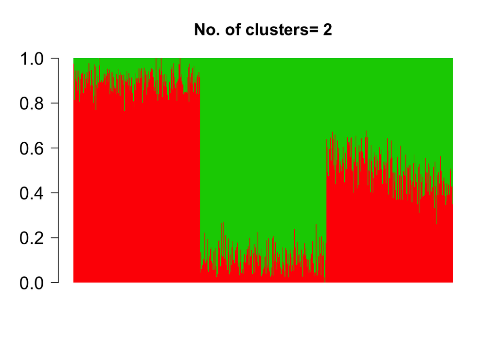

```r
barplot(t(ord_topics$omega),
        col = 2:(K+1),
        axisnames = F, space = 0, border = NA,
        main=paste("No. of clusters=", K),
        las=1, ylim=c(0,1), cex.axis=1.5, cex.main=1.4)
```

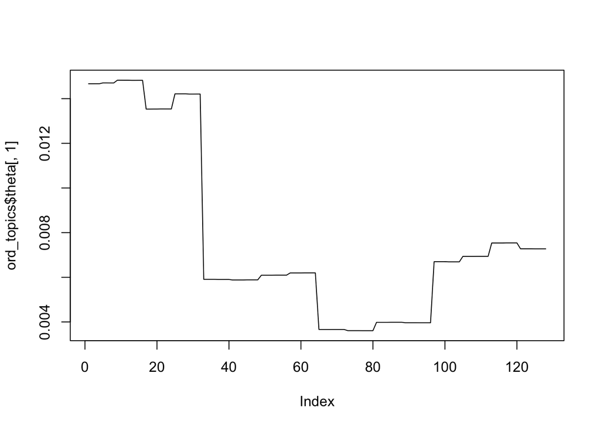

```r
plot(ord_topics$theta[,1], type="l")
```

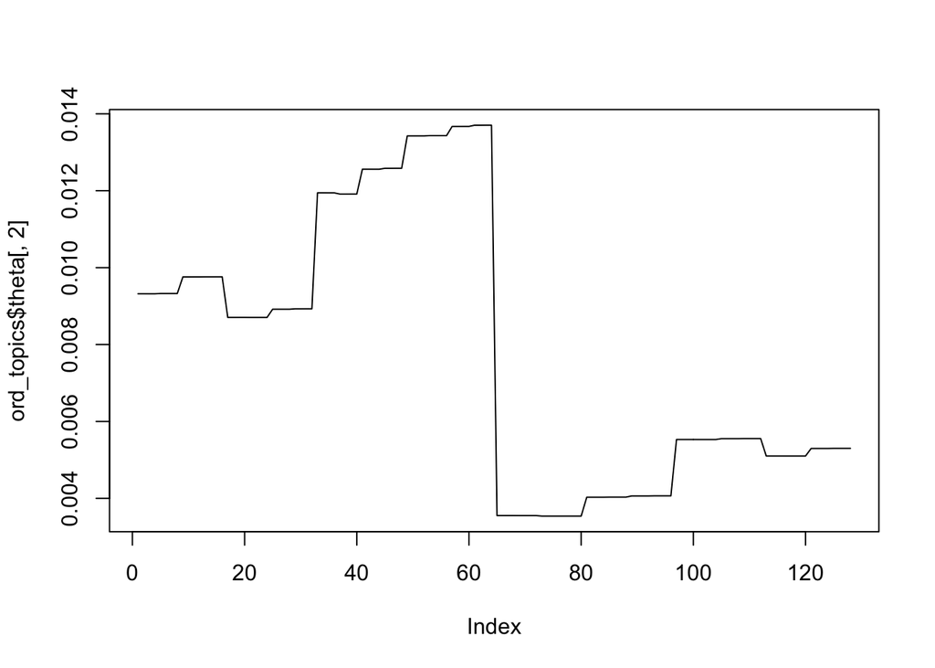

```r
plot(ord_topics$theta[,2], type="l")
```

### Scenario 3

```r
K <- 2
levels <- 7
del_beta_1 <- 10*rep(10^{1:levels});
system.time(ord_topics <- ord_topics(counts, K=2, del_beta = del_beta_1, a_mu=10, b_mu=30, ztree_options=2, tol=0.001));
```

```
##
## Estimating on a 600 document collection.
##
## Fitting a ordered topic model with 2 topics
## log posterior increase: 231294.097, 0.135, 0, done.
```

```
##    user  system elapsed
##   1.192   1.540   2.093
```

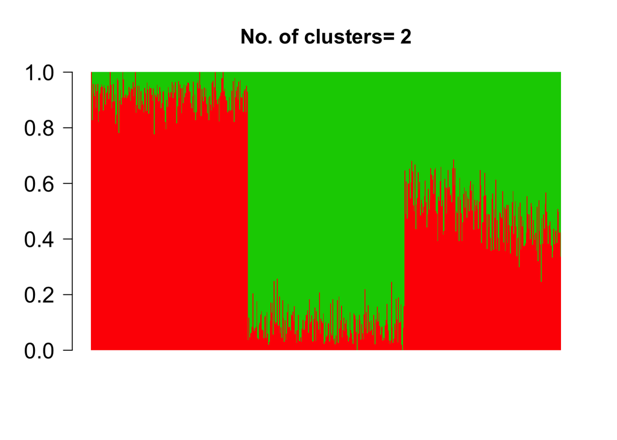

```r
barplot(t(ord_topics$omega),
        col = 2:(K+1),
        axisnames = F, space = 0, border = NA,
        main=paste("No. of clusters=", K),
        las=1, ylim=c(0,1), cex.axis=1.5, cex.main=1.4)
```

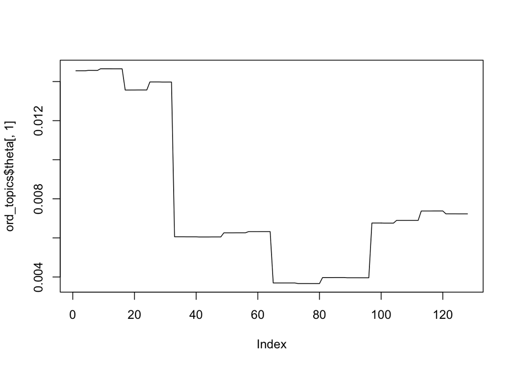

```r
plot(ord_topics$theta[,1], type="l")
```

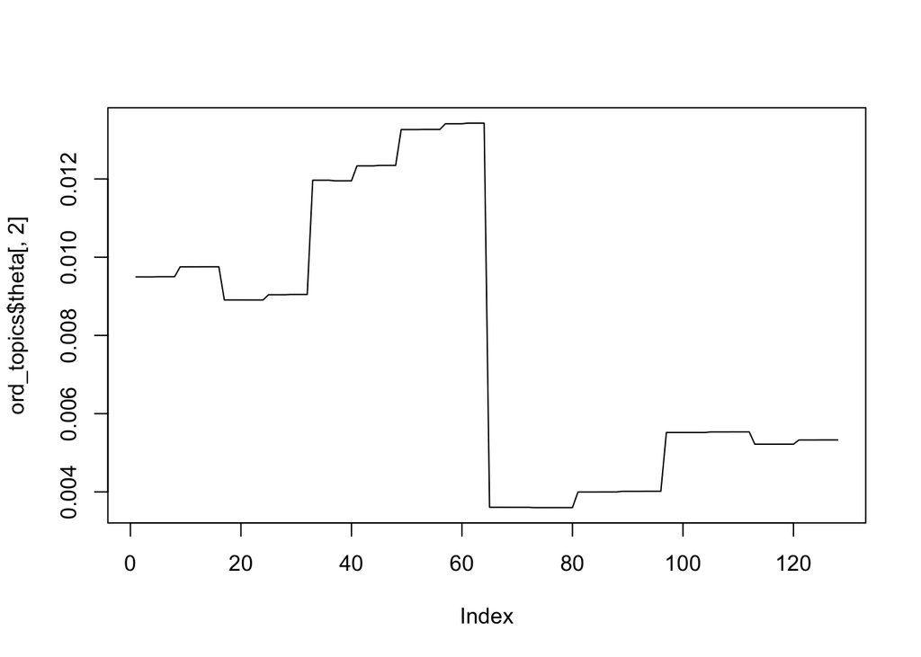

```r
plot(ord_topics$theta[,2], type="l")
```

### Scenario 4

```r
K <- 2
levels <- 7
del_beta_1 <- rep(2,levels)
system.time(ord_topics <- ord_topics(counts, K=2, del_beta = del_beta_1, a_mu=10, b_mu=30, ztree_options=2, tol=0.001));
```

```
##
## Estimating on a 600 document collection.
##
## Fitting a ordered topic model with 2 topics
## log posterior increase: 417.706, 459.962, 218.482, 4.528, 3.111, 1.586, 0.904, 0.563, 0.489, 0.369, 0.312, 0.306, 0.218, 0.195, 0.119, 0.155, 0.315, 0.141, 0.057, 0.164, 0.082, 0.084, 0.03, 0.164, 0.055, 0.073, 0.182, done.
```

```
##    user  system elapsed
##  15.942  22.102  29.088
```

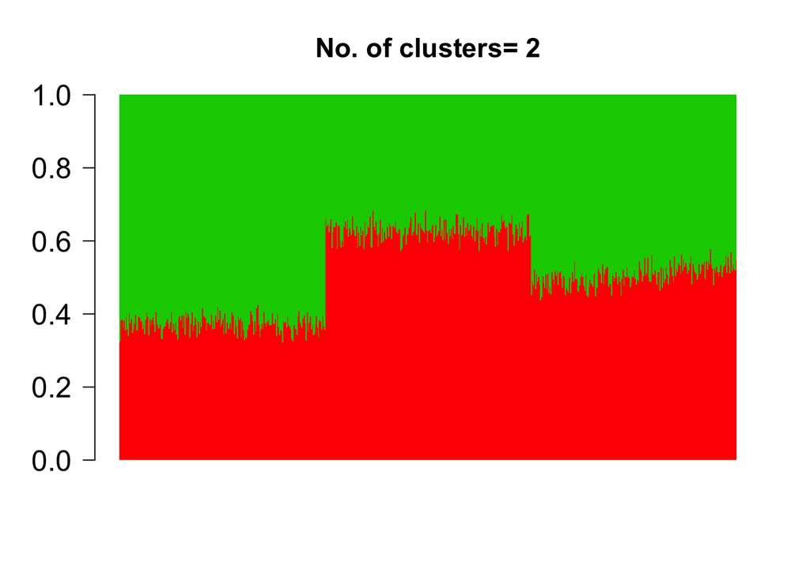

```r
barplot(t(ord_topics$omega),
        col = 2:(K+1),
        axisnames = F, space = 0, border = NA,
        main=paste("No. of clusters=", K),
        las=1, ylim=c(0,1), cex.axis=1.5, cex.main=1.4)
```

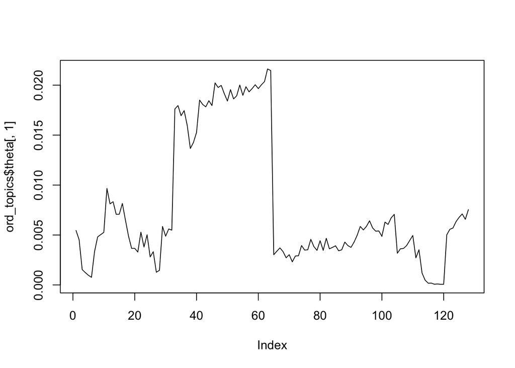

```r
plot(ord_topics$theta[,1], type="l")
```

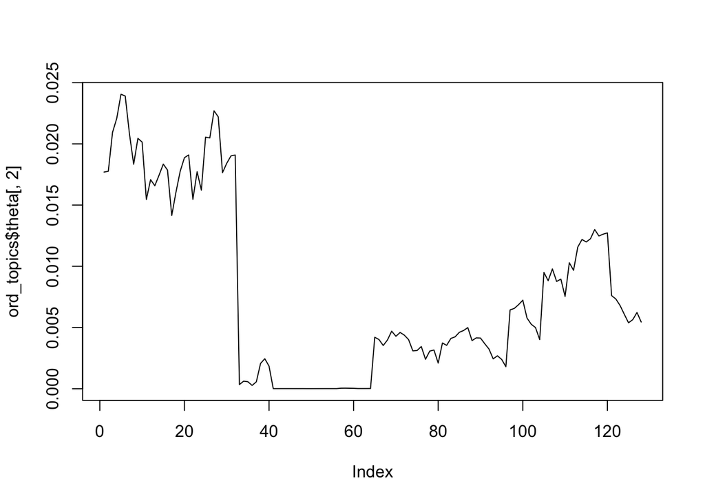

```r
plot(ord_topics$theta[,2], type="l")
```

### Scenario 5

```r
K <- 2
levels <- 7
del_beta_1 <- rep(50000,levels)
system.time(ord_topics <- ord_topics(counts, K=2, del_beta = del_beta_1, a_mu=10, b_mu=30, ztree_options=2, tol=0.001));
```

```
##
## Estimating on a 600 document collection.
##
## Fitting a ordered topic model with 2 topics
## log posterior increase: 4906584.252, 1.736, 0, done.
```

```
##    user  system elapsed
##   1.364   1.783   2.421
```

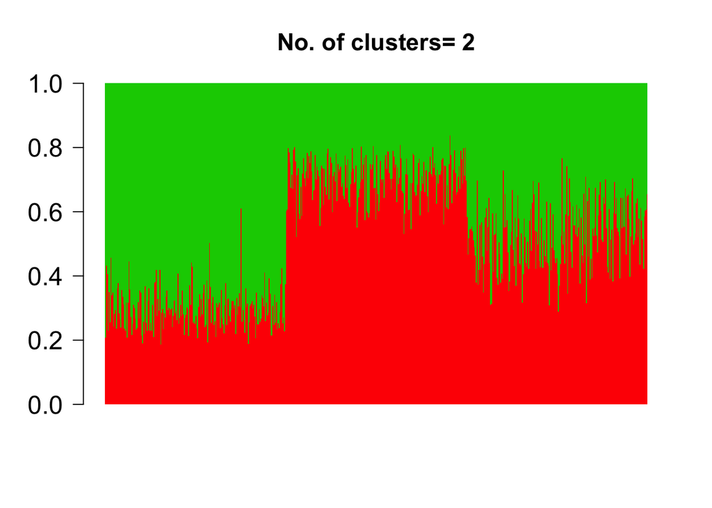

```r
barplot(t(ord_topics$omega),
        col = 2:(K+1),
        axisnames = F, space = 0, border = NA,
        main=paste("No. of clusters=", K),
        las=1, ylim=c(0,1), cex.axis=1.5, cex.main=1.4)
```

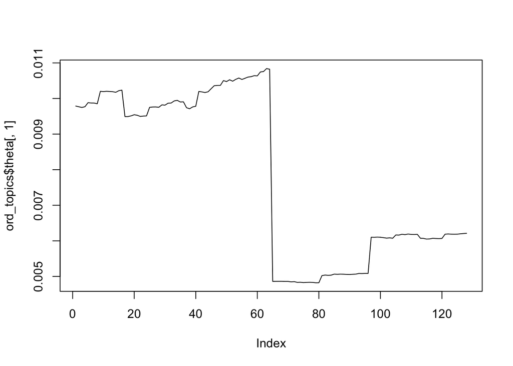

```r
plot(ord_topics$theta[,1], type="l")
```

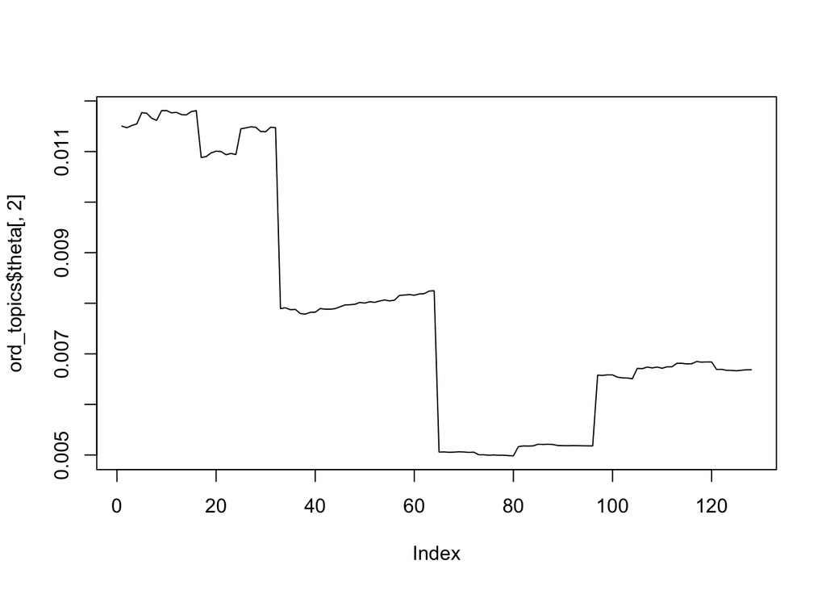

```r
plot(ord_topics$theta[,2], type="l")
```

### Scenario 6

```r
K <- 2
levels <- 7
del_beta_1 <- del_beta
system.time(ord_topics <- ord_topics(counts, K=2, del_beta = del_beta_1, a_mu=10, b_mu=30, ztree_options=2, tol=0.001));
```

[output not shown]

```
##    user  system elapsed
##  42.243  62.766  81.552
```

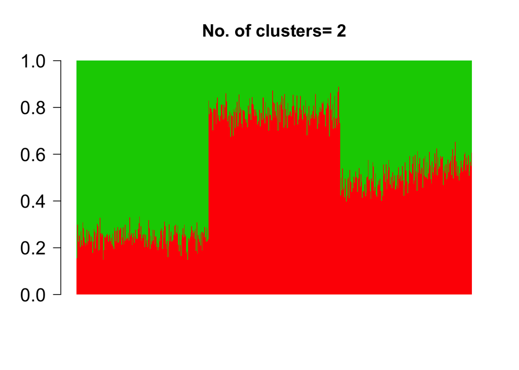

```r
barplot(t(ord_topics$omega),
        col = 2:(K+1),
        axisnames = F, space = 0, border = NA,
        main=paste("No. of clusters=", K),
        las=1, ylim=c(0,1), cex.axis=1.5, cex.main=1.4)
```

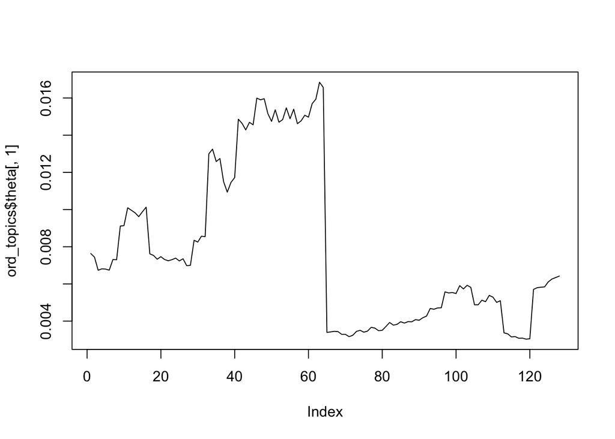

```r
plot(ord_topics$theta[,1], type="l")
```

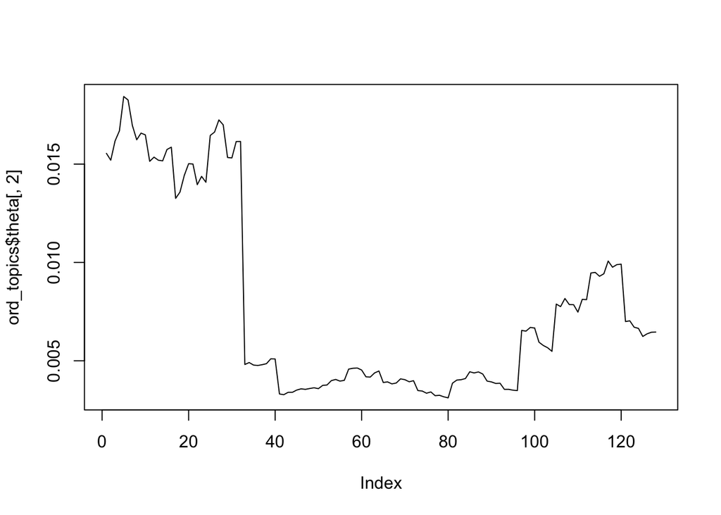

```r
plot(ord_topics$theta[,2], type="l")
```